Tài liệu này mang giấy phép Creative Commons Attribution (CC BY SA). Bản gốc copyright (c) Barba group

[@barbagroup](https://github.com/barbagroup/CFDPython)

*Thực hành CFD với Python!*

# Bài 8. Hệ phương trình Navier - Stokes cho chất lỏng không nén được. Phương pháp MAC

Hệ phương trình Navier-Stokes (tham khảo [VnCFD](https://vncfdgroup.wordpress.com/2012/04/14/bai-5-ph%C6%B0%C6%A1ng-trinh-navier-stokes/)) cho chất lỏng không nén được ($\rho = const$) hai chiều có dạng:

$$ \begin{eqnarray*} \nabla \cdot\vec{v} &=& 0 \qquad (1)\\ \frac{\partial \vec{v}}{\partial t}+(\vec{v}\cdot\nabla)\vec{v} &=& -\frac{1}{\rho}\nabla p + \nu \nabla^2\vec{v} \qquad (2) \end{eqnarray*} $$

Trong đó, phương trình (1) còn gọi là phương trình liên tục, được rút ra từ định luật bảo toàn khối lượng, phương trình (2) - phương trình động lượng, được rút ra từ định luật bảo toàn động lượng. Hệ phương trình này có dạng khai triển:

$$\frac {\partial u}{\partial x} + \frac {\partial v}{\partial y} = 0 \qquad (3)$$$$\frac{\partial u}{\partial t}+u\frac{\partial u}{\partial x}+v\frac{\partial u}{\partial y} = -\frac{1}{\rho}\frac{\partial p}{\partial x}+\nu \left(\frac{\partial^2 u}{\partial x^2}+\frac{\partial^2 u}{\partial y^2} \right) \qquad (4)$$$$\frac{\partial v}{\partial t}+u\frac{\partial v}{\partial x}+v\frac{\partial v}{\partial y} = -\frac{1}{\rho}\frac{\partial p}{\partial y}+\nu\left(\frac{\partial^2 v}{\partial x^2}+\frac{\partial^2 v}{\partial y^2}\right) \qquad (5)$$

Với chất lỏng có khối lượng riêng $\rho$ không đổi, hệ phương trình có ba ẩn $(u, v, p)$. Tuy nhiên trong phương trình (1) chỉ có hai ẩn vận tốc u và v, thiếu mối liên hệ trực tiếp với áp suất p. Để giải hệ phương trình này có nhiều hướng như thêm tính nén được nhân tạo vào hệ phương trình, hiệu chỉnh áp suất nhờ phương trình Poisson. Trong mỗi hướng lại có nhiều phương pháp khác nhau. Chúng ta sẽ xem xét phương pháp hiệu chỉnh áp suất. Phương trình Poisson cho áp suất có thể thu được bằng các biến đổi sau:

Đạo hàm phương trình (4) theo $x$ ta có:

$$\frac{\partial}{\partial t}\frac{\partial u}{\partial x}+\left(\frac{\partial u}{\partial x}\right)^2+u\frac{\partial^2 u}{\partial x^2}+\frac{\partial v}{\partial x}\frac{\partial u}{\partial y}+v\frac{\partial^2 u}{\partial x \partial y} = -\frac{1}{\rho}\frac{\partial^2 p}{\partial x^2}+\nu \frac{\partial}{\partial x}(\nabla^2 u) \qquad (6)$$

Đạo hàm phương trình (5) theo $y$ ta có:

$$\frac{\partial}{\partial t}\frac{\partial v}{\partial y}+\left(\frac{\partial v}{\partial y}\right)^2+v\frac{\partial^2 v}{\partial y^2}+\frac{\partial v}{\partial x}\frac{\partial u}{\partial y}+u\frac{\partial^2 v}{\partial x \partial y} = -\frac{1}{\rho}\frac{\partial^2 p}{\partial y^2}+\nu \frac{\partial}{\partial y}(\nabla^2 v) \qquad (7)$$

Cộng hai vế của phương trình (6) và (7), sử dụng các biến đổi của phương trình liên tục (3) $[(3), \partial (3) /\partial x, \partial (3) /\partial y, \partial^2 (3) /\partial x^2 + \partial^2 (3) /\partial y^2 ]$ ta thu được phương trình Poisson cho áp suất như sau: $$\Delta p = 2\rho\left(\frac{\partial u}{\partial x} \frac{\partial v}{\partial y} - \frac{\partial u}{\partial y} \frac{\partial v}{\partial x}\right) \qquad (8)$$

**Sơ đồ sai phân**

Sử dụng sơ đồ sai phân tiến theo thời gian cho phương trình (2) ta có:

$$\frac{\vec{v}^{n+1} - \vec{v}^n}{dt}+(\vec{v}^n\cdot\nabla)\vec{v}^n = -\frac{1}{\rho}\nabla p^n + \nu \nabla^2\vec{v}^n \qquad (9)$$

Áp dụng toán tử div cho hai vế phương trình ta được:

$$\frac{\nabla \vec{v}^{n+1} - \nabla \vec{v}^n}{dt}+\nabla(\vec{v}^n\cdot\nabla \vec{v}^n) = -\frac{1}{\rho}\nabla^2 p^{n+1} + \nu \nabla( \nabla^2\vec{v}^n) \qquad (10)$$

Điều chúng ta mong muốn đó là nghiệm v ở bước thời gian n+1 thỏa mãn phương trình liên tục $(\nabla \vec{v}^{n+1} = 0)$ tuy nhiên, nghiệm v ở bước thời gian n có thể ko thỏa mãn điều kiện này. Do đó chúng ta cần hiệu chỉnh áp suất để thu được kết quả chính xác nhất. Để có được điều này, thay vì giải phương trình Poisson (8), chúng ta giải phương trình rút ra từ (10):

$$ \frac{1}{\rho}\Delta p^{n+1} =\frac {\nabla \vec{v}^n}{dt}-\nabla(\vec{v}^n\cdot\nabla \vec{v}^n) + \nu \nabla^2( \nabla\vec{v}^n)$$

hay là: $$\Delta p = 2\rho\left(\frac{\partial u}{\partial x} \frac{\partial v}{\partial y} - \frac{\partial u}{\partial y} \frac{\partial v}{\partial x}\right) + \rho \frac {\partial}{\partial t}(\frac{\partial u}{\partial x} + \frac{\partial v}{\partial y})\qquad (11)$$

Ta có sơ đồ sai phân sau:

Phương trình động lượng theo phương x: $$ \begin{split} & \frac{u_{i,j}^{n+1}-u_{i,j}^{n}}{\Delta t}+u_{i,j}^{n}\frac{u_{i,j}^{n}-u_{i-1,j}^{n}}{\Delta x}+v_{i,j}^{n}\frac{u_{i,j}^{n}-u_{i,j-1}^{n}}{\Delta y} = \\ & \qquad -\frac{1}{\rho}\frac{p_{i+1,j}^{n}-p_{i-1,j}^{n}}{2\Delta x}+\nu\left(\frac{u_{i+1,j}^{n}-2u_{i,j}^{n}+u_{i-1,j}^{n}}{\Delta x^2}+\frac{u_{i,j+1}^{n}-2u_{i,j}^{n}+u_{i,j-1}^{n}}{\Delta y^2}\right) \end{split} $$ Phương trình động lượng theo phương y: $$ \begin{split} &\frac{v_{i,j}^{n+1}-v_{i,j}^{n}}{\Delta t}+u_{i,j}^{n}\frac{v_{i,j}^{n}-v_{i-1,j}^{n}}{\Delta x}+v_{i,j}^{n}\frac{v_{i,j}^{n}-v_{i,j-1}^{n}}{\Delta y} = \\ & \qquad -\frac{1}{\rho}\frac{p_{i,j+1}^{n}-p_{i,j-1}^{n}}{2\Delta y} +\nu\left(\frac{v_{i+1,j}^{n}-2v_{i,j}^{n}+v_{i-1,j}^{n}}{\Delta x^2}+\frac{v_{i,j+1}^{n}-2v_{i,j}^{n}+v_{i,j-1}^{n}}{\Delta y^2}\right) \end{split} $$

Phương trình Poisson cho áp suất:

$$ \begin{split} & \frac{p_{i+1,j}^{n}-2p_{i,j}^{n}+p_{i-1,j}^{n}}{\Delta x^2}+\frac{p_{i,j+1}^{n}-2p_{i,j}^{n}+p_{i,j-1}^{n}}{\Delta y^2} = \\ & \qquad 2\rho \left[\frac{u_{i+1,j}-u_{i-1,j}}{2\Delta x}\frac{v_{i,j+1}-v_{i,j-1}}{2\Delta y} - \frac{u_{i,j+1}-u_{i,j-1}}{2\Delta y}\frac{v_{i+1,j}-v_{i-1,j}}{2\Delta x}\right] + \frac{\rho}{\Delta t}\left(\frac{u_{i+1,j}-u_{i-1,j}}{2\Delta x}+\frac{v_{i,j+1}-v_{i,j-1}}{2\Delta y}\right) \end{split} $$

Như vậy ta có công thức xác định nghiệm u, v, p:

Vận tộc u:

$$ \begin{split} u_{i,j}^{n+1} = u_{i,j}^{n} & - u_{i,j}^{n} \frac{\Delta t}{\Delta x} \left(u_{i,j}^{n}-u_{i-1,j}^{n}\right) - v_{i,j}^{n} \frac{\Delta t}{\Delta y} \left(u_{i,j}^{n}-u_{i,j-1}^{n}\right) \\ & - \frac{\Delta t}{\rho 2\Delta x} \left(p_{i+1,j}^{n}-p_{i-1,j}^{n}\right) \\ & + \nu \left(\frac{\Delta t}{\Delta x^2} \left(u_{i+1,j}^{n}-2u_{i,j}^{n}+u_{i-1,j}^{n}\right) + \frac{\Delta t}{\Delta y^2} \left(u_{i,j+1}^{n}-2u_{i,j}^{n}+u_{i,j-1}^{n}\right)\right) \end{split} $$

Vận tốc v:

$$ \begin{split} v_{i,j}^{n+1} = v_{i,j}^{n} & - u_{i,j}^{n} \frac{\Delta t}{\Delta x} \left(v_{i,j}^{n}-v_{i-1,j}^{n}\right) - v_{i,j}^{n} \frac{\Delta t}{\Delta y} \left(v_{i,j}^{n}-v_{i,j-1}^{n})\right) \\ & - \frac{\Delta t}{\rho 2\Delta y} \left(p_{i,j+1}^{n}-p_{i,j-1}^{n}\right) \\ & + \nu \left(\frac{\Delta t}{\Delta x^2} \left(v_{i+1,j}^{n}-2v_{i,j}^{n}+v_{i-1,j}^{n}\right) + \frac{\Delta t}{\Delta y^2} \left(v_{i,j+1}^{n}-2v_{i,j}^{n}+v_{i,j-1}^{n}\right)\right) \end{split} $$

Áp suất p:

$$ \begin{split} p_{i,j}^{n} = & \frac{\left(p_{i+1,j}^{n}+p_{i-1,j}^{n}\right) \Delta y^2 + \left(p_{i,j+1}^{n}+p_{i,j-1}^{n}\right) \Delta x^2}{2\left(\Delta x^2+\Delta y^2\right)} \\ & -\frac{\rho\Delta x^2\Delta y^2}{\left(\Delta x^2+\Delta y^2\right)} \\ & \qquad \left[\frac{u_{i+1,j}-u_{i-1,j}}{2\Delta x}\frac{v_{i,j+1}-v_{i,j-1}}{2\Delta y} - \frac{u_{i,j+1}-u_{i,j-1}}{2\Delta y}\frac{v_{i+1,j}-v_{i-1,j}}{2\Delta x} + \frac{1}{2\Delta t}\left(\frac{u_{i+1,j}-u_{i-1,j}}{2\Delta x}+\frac{v_{i,j+1}-v_{i,j-1}}{2\Delta y}\right)\right] \end{split} $$

Thực ra phương pháp MAC hay Projection (bài 9) thường sử dụng `lưới so le (staggered grid)`, tức là các biến khác nhau (u, v, p) sẽ được xách định tại các điểm lưới khác nhau. Tuy nhiên để đơn giản, ở đây chúng ta sử dụng lưới bình thường.

**Bài toán**

Bài toán thường dùng để kiểm tra các phương pháp giải hệ phương trình Navier-Stokes đó là dòng chảy với tường dịch chuyển (Cavity flow). Tại thời điểm ban đầu chất lỏng trong hố đứng yên, nắp hố chuyển động đều.

[figure not shown]

Điều kiện ban đầu:

$u, v, p = 0$ trên miền [0,1]x[0,1]

Điều kiện biên cho vận tốc:

$u=1$ tại $y=1$ (nắp hố) ; $u, v=0$ tại thành hố

Điều kiện biên cho áp suất:

$\frac{\partial p}{\partial y}=0$ tại $y=0$ ; $\frac{\partial p}{\partial x}=0$ tại $x=0$ ; $p=0$ tại $y=1$.

**coding**

Trình tự các bước tính toán như sau:

*Bước 1* - giải phương trình Poisson, tìm áp suất p. Các bước thực hiện gần giống với bài 4. Điểm khác, thay vì kiểm tra điều kiện 'chuẩn', ta chỉ giới hạn thực hiện vòng lặp 'ntp' bước.

*Bước 2* - tìm vận tốc u, v

```python
import numpy as np
import matplotlib.pyplot as plt
from matplotlib import cm
from mpl_toolkits.mplot3d import Axes3D

#hàm tìm p:
#để rút gọn công thức tính p ta sẽ viết thêm hàm phụ tính hạng tử thứ 2 vế phải
def f(res, u, v, dx, dy):
    res[1:-1, 1:-1] = ((u[1:-1, 2:] - u[1:-1, 0:-2])/(2*dx) * (v[2:, 1:-1] - v[0:-2, 1:-1])/(2*dy) - \
                       (u[2:, 1:-1] - u[0:-2, 1:-1])/(2*dy) * (v[1:-1, 2:] - v[1:-1, 0:-2])/(2*dx) +\
                       1./(2*dt)*((u[1:-1, 2:] - u[1:-1, 0:-2])/(2*dx) + (v[2:, 1:-1] - v[0:-2, 1:-1])/(2*dy)))

    return res

#giải phương trình Poisson cho áp suất
def poisson_p(p, res, dx, dy, rho):
    pn = np.empty_like(p) #mảng chứa giá trị tạm thời

    #các hằng số
    dx2 = dx**2
    dy2 = dy**2
    for n in range(ntp):
        pn = p.copy() #lưu giá trị ở bước n

        #tính giá trị ở bước n+1
        p[1:-1, 1:-1] = ((pn[1:-1, 2:] + pn[1:-1, 0:-2])*dy2 + \
                         (pn[2:, 1:-1] + pn[0:-2, 1:-1])*dx2) / (2*(dx2 + dy2)) -\
                          rho*dx2*dy2/(dx2 + dy2)*res[1:-1, 1:-1]

        #điều kiện biên áp suất
        p[-1, :] = 0 #p = 0, y = 2
        p[0, :] = p[1, :] #dp/dy = 0, y = 0
        p[:, 0] = p[:, 1] #dp/dx = 0, x = 0
        p[:, -1] = p[:, -2] #dp/dx = 0, x = 2

    return p


def solver_u(u, v, p, nt, dx, dy, rho, nu):
    #các câu lệnh sau có thể sử dụng để tạo ra 'bản sao' mảng
    un = u.copy()
    vn = np.zeros_like(v)
    res = np.ones_like(p)

    #các hằng số thường dùng
    dtbdx = dt/dx
    dtbdy = dt/dy
    nudtbdx2 = nu*dt/(dx**2)
    nudtbdy2 = nu*dt/(dy**2)
    dtbdx2r = dtbdx/(2*rho)
    dtbdy2r = dtbdy/(2*rho)

    for n in range(nt):
        #lưu nghiệm ở bước n
        un = u.copy()
        vn = v.copy()

        #tìm nghiệm ở bước n+1
        #1. giải phương trình Poisson tìm áp suất p
        res = f(res, u, v, dx, dy)
        p = poisson_p(p, res, dx, dy, rho)

        #2. tính u, v
        u[1:-1, 1:-1] = un[1:-1, 1:-1] - un[1:-1, 1:-1]*dtbdx*(un[1:-1, 1:-1] - un[1:-1, 0:-2]) -\
                        vn[1:-1, 1:-1]*dtbdy*(un[1:-1, 1:-1] - un[0:-2, 1:-1]) -\
                        dtbdx2r*(p[1:-1, 2:] - p[1:-1, 0:-2]) +\
                        nudtbdx2*(un[1:-1, 2:] - 2*un[1:-1, 1:-1] + un[1:-1, 0:-2]) +\
                        nudtbdy2*(un[2:, 1:-1] - 2*un[1:-1, 1:-1] + un[0:-2, 1:-1])

        v[1:-1, 1:-1] = vn[1:-1, 1:-1] - un[1:-1, 1:-1]*dtbdx*(vn[1:-1, 1:-1] - vn[1:-1, 0:-2]) -\
                        vn[1:-1, 1:-1]*dtbdy*(vn[1:-1, 1:-1] - vn[0:-2, 1:-1]) -\
                        dtbdy2r*(p[2::, 1:-1] - p[0:-2, 1:-1]) +\
                        nudtbdx2*(vn[1:-1, 2:] - 2*vn[1:-1, 1:-1] + vn[1:-1, 0:-2]) +\
                        nudtbdy2*(vn[2:, 1:-1] - 2*vn[1:-1, 1:-1] + vn[0:-2, 1:-1])

        #điều kiện biên vận tốc
        u[0, :] = 0
        u[-1, :] = 1
        u[:, 0] = 0
        u[:, -1] = 0
        v[0, :] = 0
        v[-1, :] = 0
        v[:, 0] = 0
        v[:, -1] = 0

    return u, v, p #trả về nghiệm u, v, p
```

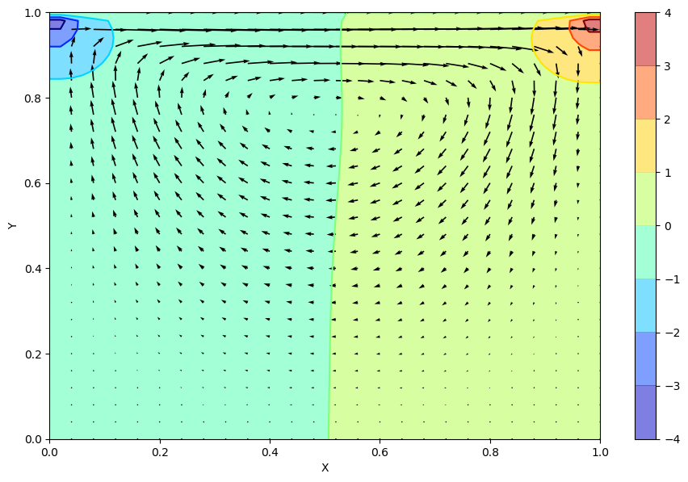

```python
#chia lưới
nx = 51
ny = 51
x, dx = np.linspace(0, 1, nx, retstep=True)
y, dy = np.linspace(0, 1, ny, retstep=True)

#thông số bài toán
rho = 1.    #khối lượng riêng
nu = 0.1    #độ nhớt động học
dt = 0.001  #bước thời gian dt
ntp = 200   #số bước lặp tìm áp suất p

#mảng chứa nghiệm
u = np.zeros((ny, nx))
v = np.zeros((ny, nx))
p = np.zeros((ny, nx))

#điều kiện ban đầu và điều kiện biên
u[-1, :] = 1

#tìm nghiệm ở bước thời gian nt = 100
u, v, p = solver_u(u, v, p, 200, dx, dy, rho, nu)

#biểu diễn nghiệm
fig = plt.figure(figsize=(11,7), dpi=100)
X, Y = np.meshgrid(x, y)
plt.contourf(X, Y, p, alpha=0.5, cmap=cm.jet)
plt.colorbar()
plt.contour(X, Y, p, cmap=cm.jet)

#biểu diễn vector vận tốc ::2 - phần tử thứ i chia hết cho 2
plt.quiver(X[::2, ::2], Y[::2, ::2], u[::2, ::2], v[::2, ::2])
plt.xlabel('X')
plt.ylabel('Y')
plt.show()
```

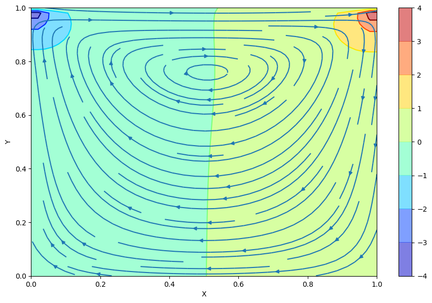

```python
#biểu diễn nghiệm
fig = plt.figure(figsize=(11,7), dpi=100)
X, Y = np.meshgrid(x, y)
plt.contourf(X, Y, p, alpha=0.5, cmap=cm.jet)
plt.colorbar()
plt.contour(X, Y, p, cmap=cm.jet)

#biểu diễn đường dòng
plt.streamplot(X, Y, u, v,)
plt.xlabel('X')
plt.ylabel('Y')
plt.show()
```

Kết quả thu được cho ta thấy có hai vùng áp suất'riêng biệt' được tạo ra do 'nắp' di chuyển. Tại thời điểm đang xét, chỉ mới xuất hiện 'xoáy lớn' ở trung tâm, chưa có xoáy nhỏ ở góc (thực ra nếu tăng mật độ đường dòng lên có thể ta sẽ thấy chúng). Nếu tiếp tục tăng thời gian tính toán, đến một thời điểm nào đó sẽ thu được xoáy ở góc nhưng đồng thời dòng chảy không còn ổn định vì điều kiện ổn định của sơ đồ không thỏa mãn:

[figure not shown]

Ở bài sau chúng ta sẽ xem xét phương pháp Projection cùng điều kiện ổn định, cũng như sẽ học cách tạo hình động hoặc video như trên.

### Bài 9. Hệ phương trình Navier - Stokes cho chất lỏng không nén được. Phương pháp Projection